# Tipps für logistische Regression

Fabio Votta

18 Dezember 2017

Die logistische Regression kann anfangs Kopfschmerzen verursachen. Während die Struktur und die Idee der “normalen” Regression entsprechen, kann die Interpretation der b’s (d.h. der Regressionskoeffizienten) schwieriger sein.

Dieser Post bietet eine praktische Funktion zum Konvertieren der logits (das wird von ´glm´ ausgegeben) in eine Wahrscheinlichkeit.

### Packages einladen

```r
#install.packages("pacman")
#pacman::p_install_gh("favstats/favstats")

pacman::p_load(tidyverse, magrittr, haven, sjPlot, sjmisc, texreg, car, psych, knitr, labelled, broom, favstats)
```

### Datensatz einladen

```r
allbus <- read_spss("allbus2014.sav")
allb_sub <- allbus %>%
      select(V84, V86, V81, V419)  %>%
      rename(alter = V84,
       bildung = V86,
       geschl  = V81,
       einkommen  = V419) %>%
      mutate(alter0 = alter - 18,
       bildung_rec = ifelse(bildung == 6 | bildung == 7, NA, bildung - 1),
       geschl_rec = ifelse(geschl == 2, 0, 1)) %>%
      mutate_all(as.numeric) # alle Werte als numerisch ausgeben
```

### Neue Variable: Einkommen Hoch

```r
allb_sub %<>%
    mutate(einkommen_h = ifelse(einkommen > 2500, 1, 0))

allb_sub %>%
  janitor::tabyl(einkommen_h) %>%
  kable()
```

| einkommen_h | n | percent | valid_percent |
| --- | --- | --- | --- |
| 0 | 2655 | 0.7649092 | 0.8662316 |
| 1 | 410 | 0.1181216 | 0.1337684 |
| NA | 406 | 0.1169692 | NA |

> Tipp: Der `%<>%` Operator aus dem `magrittr` package erspart ein wenig Tipparbeit. Stattdessen könnten wir auch (wie üblich) schreiben:

```r
allb_sub <- allb_sub %>%
    mutate(einkommen_h = ifelse(einkommen > 2500, 1, 0))
```

### Berechnen wir jetzt unser Modell:

Die Syntax für ein logistisches Modell ähnelt sehr der Syntax für ein lineares Modell. Man benutzt einfach die Funktion `glm()` (steht für *generalized linear model*) und spezifiziert am Ende `family = "binomial"` um ein Modell für ein dichotomes logistisches Modell zu berechnen.

```r
mod1 <- glm(einkommen_h ~ bildung_rec + geschl_rec + alter0,
            data = allb_sub, family = "binomial")

htmlreg(mod1)
```

Statistical models

|  | **Model 1** |  |
| --- | --- | --- |
| (Intercept) | -5.64*** |  |
|  | (0.26) |  |
| bildung_rec | 0.75*** |  |
|  | (0.05) |  |
| geschl_rec | 1.85*** |  |
|  | (0.14) |  |
| alter0 | 0.02*** |  |
|  | (0.00) |  |
| AIC | 1969.52 |  |
| BIC | 1993.60 |  |
| Log Likelihood | -980.76 |  |
| Deviance | 1961.52 |  |
| Num. obs. | 3039 |  |
| p < 0.001, p < 0.01, p < 0.05 |  |  |

> Wenn der Koeffizient (logit) positiv ist, ist der Effekt dieses Prädiktors positiv und umgekehrt.

Hier sind die Koeffizienten *positiv*, was anzeigt, dass sowohl höhere Bildung und Alter sowie männliches Geschlecht die Wahrscheinlichkeit erhöht in einer höheren Einkommensklasse zu sein (Einkommen > 2500). Neben der Signifikanz der Koeffizienten, lässt sich aus dem logit allerdings nicht direkt (zumindest nicht intuitiv) die Stärke des Effekts ablesen sondern nur die **Richtung**.

Die folgenden 3 Schritte konvertieren einen logit-Koeffizienten in eine Wahrscheinlichkeit:

**1. Extrahiere die logit-Koeffizienten**

**2. Berechne zunächst das $\hat z_i$ (vorhergesagter logit) und dann damit die Odds $e^{\hat z_i}$**

**3. Berechne die Wahrscheinlichkeit mit Hilfe der Odds $\frac{e^{\hat z_i}}{1 +e^{\hat z_i}}$**

### Didaktisches Beispiel

*Frage: Wie wahrscheinlich ist es, dass eine 30-Jährige Frau mit höchster Bildung ein Netto-Einkommen über 2500 Euro pro Monat bekommt?*

**1. Extrahiere die logit-Koeffizienten**

Um es ein bisschen zu vereinfachen habe ich eine kleine Funktion geschrieben, welche die Koeffizienten im *wide* Format ausgibt:

```r
tidy_wide <- function(model) {
  model_wide <- tidy(model) %>% # tidy extrahiert die Parameter
  select(term, estimate) %>%    # wir brauchen nur die logit-koeffs
  spread(term, estimate) %>%    # konvertieren in wide format
  rename(intercept = `(Intercept)`) # umbenennen
  return(model_wide)            # gib model_wide aus
}
```

Probieren wir diese doch einmal aus:

```r
mod1_wide <- tidy_wide(mod1)

mod1_wide %>%
  kable()
```

| intercept | alter0 | bildung_rec | geschl_rec |
| --- | --- | --- | --- |
| -5.640335 | 0.0172347 | 0.7498078 | 1.851376 |

**2. Berechne zunächst das $\hat z_i$ (vorhergesagter logit) auf folgende Art und Weise:**

$$\hat z_i = a + b \times X_i$$
Die **Odds** (Chancen) sind einfach die eulersche Zahl hoch die logits (wird mit `exp()` berechnet)

$$e^{\hat z_i} = Odds$$

```r
mod1_wide %<>%
  mutate(z = intercept + 12 * alter0 + 4 * bildung_rec + 0 * geschl_rec)


mod1_wide %>%
  kable()
```

| intercept | alter0 | bildung_rec | geschl_rec | z |
| --- | --- | --- | --- | --- |
| -5.640335 | 0.0172347 | 0.7498078 | 1.851376 | -2.434287 |

**3. Jetzt wo die odds bekannt sind, können diese einfach in Warscheinlichkeiten umgerechnet werden mit der folgenden Formel:**

$$p_i(y=1) = \frac{1}{1 + e^{- \hat z_i}} = \frac{e^{\hat z_i}}{1 +e^{\hat z_i}} = Wahrscheinlichkeit$$

Das Ergebnis ist die Wahrscheinlichkeit, dass die Ausprägung 1 (hier: hohes Einkommen) unter den angegeben Prädiktoren eintritt.

*Formel 1*

```r
mod1_wide %<>%
  mutate(p = 1 / (1 + exp(-z)))

mod1_wide %>%
  kable()
```

| intercept | alter0 | bildung_rec | geschl_rec | z | p |
| --- | --- | --- | --- | --- | --- |
| -5.640335 | 0.0172347 | 0.7498078 | 1.851376 | -2.434287 | 0.0805952 |

*Formel 2*

```r
mod1_wide %<>%
  mutate(p = exp(z) / (1 + exp(z)))

mod1_wide %>%
  kable()
```

| intercept | alter0 | bildung_rec | geschl_rec | z | p |
| --- | --- | --- | --- | --- | --- |
| -5.640335 | 0.0172347 | 0.7498078 | 1.851376 | -2.434287 | 0.0805952 |

Oder als Funktion:

```r
logit2prob <- function(logit) { # logit ist der input
  odds <- exp(logit)          # e hoch logit = odds
  prob <- odds / (1 + odds)   # odds / 1 + odds = Wahrscheinlichkeit
  return(prob)               # gibt Wahrscheinlichkeit zurück
}
```

Anwendung:

```r
mod1_wide %<>%
  mutate(p = logit2prob(z))

mod1_wide %>%
  kable()
```

| intercept | alter0 | bildung_rec | geschl_rec | z | p |
| --- | --- | --- | --- | --- | --- |
| -5.640335 | 0.0172347 | 0.7498078 | 1.851376 | -2.434287 | 0.0805952 |

Laut Model 1 beträgt die Wahrscheinlichkeit für eine 30 - Jährige Frau mit höchstem Bildungsabschluss über 2500 Euro im Monat zu verdienen bei 8.06%.

### Andere Methoden

```r
predict(mod1, data.frame(alter0 = 12,
                         bildung_rec = 4,
                         geschl_rec = 0),
        type = "response")
```

```
##          1
## 0.08059523
```

Wenn der logit also negativ ist, liegt die zugehörige Wahrscheinlichkeit unter 50% und umgekehrt (positives logit <-> Wahrscheinlichkeit über 50%).

Mit dem Package `sjPlot` lässt sich auch eine logistische Regression sehr schön darstellen. Man muss dazu **nichts** zusätzlich angeben, da die Funktion automatisch ein logistisches Modell entdeckt und die entsprechenden Werte zurückgibt.

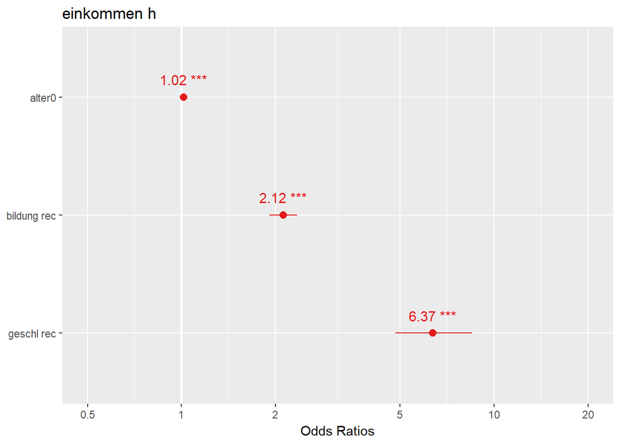

```r
library(sjPlot)

plot_model(mod1, show.values = T, show.p = T, show.data = T)
```

**Die Wahrscheinlichkeiten mit zunehmenden Alter**

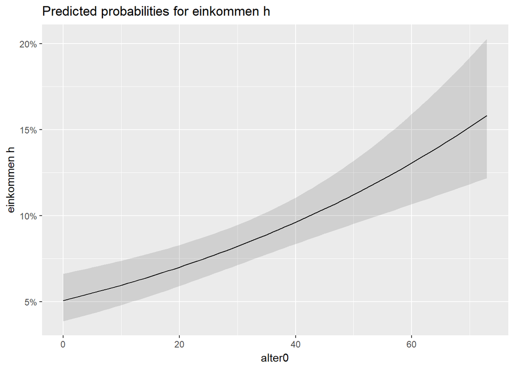

```r
plot_model(mod1, terms = "alter0", type = "pred")
```

**Die Wahrscheinlichkeiten mit zunehmenden Alter und Bildung**

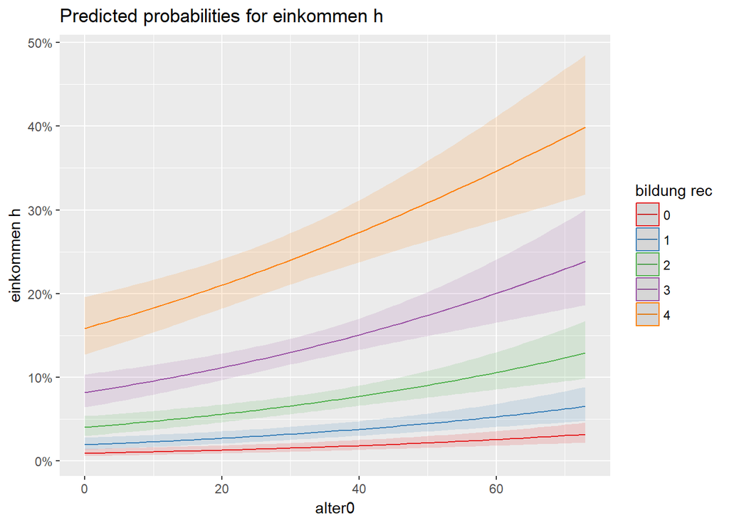

```r
plot_model(mod1, terms = c("alter0", "bildung_rec"), type = "pred")
```

**Die Wahrscheinlichkeiten mit zunehmenden Alter, Bildung, getrennt nach Geschlecht**

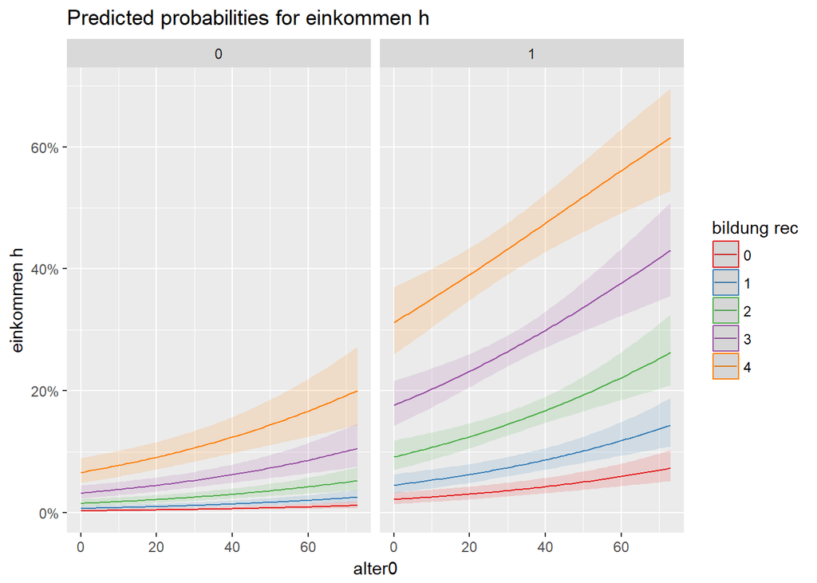

```r
plot_model(mod1, terms = c("alter0", "bildung_rec", "geschl_rec"), type = "pred")
```

```r
logit_seq <- seq(-10, 10, by = 2)
prob_seq <- round(logit2prob(logit_seq), 3)

df <- data.frame(Logit = logit_seq,
                 Wahrscheinlichkeit = prob_seq)
kable(df)
```

| Logit | Wahrscheinlichkeit |
| --- | --- |
| -10 | 0.000 |
| -8 | 0.000 |
| -6 | 0.002 |
| -4 | 0.018 |
| -2 | 0.119 |
| 0 | 0.500 |
| 2 | 0.881 |
| 4 | 0.982 |
| 6 | 0.998 |
| 8 | 1.000 |
| 10 | 1.000 |

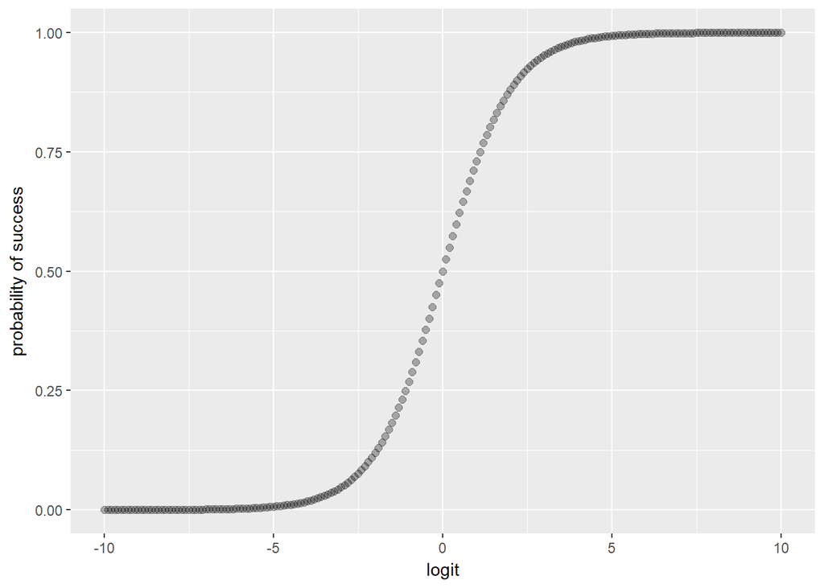

```r
logit_seq <- seq(-10, 10, by = .1)

prob_seq <- logit2prob(logit_seq)

df <- data.frame(Logit = logit_seq,
                 Wahrscheinlichkeit = prob_seq)

ggplot(df) +
  aes(x = logit_seq, y = prob_seq) +
  geom_point(size = 2, alpha = .3) +
  labs(x = "logit", y = "probability of success")
```